# Reproducible Research: Peer Assessment 1

Fabio Andrade

26 de maio de 2016

## Loading and preprocessing the data

Unzip data to obtain a csv file.

```r
unzip("repdata-data-activity.zip",exdir = "data")
```

Reading the data into activity data frame and show some summary statistics

```r
library(Hmisc)
dataimport <- read.csv("data/activity.csv", stringsAsFactors=FALSE)
describe(dataimport)
```

```
## dataimport
##
##  3  Variables      17568  Observations
## ---------------------------------------------------------------------------
## steps
##       n missing  unique    Info    Mean     .05     .10     .25     .50
##   15264    2304     617    0.62   37.38     0.0     0.0     0.0     0.0
##     .75     .90     .95
##    12.0    86.0   252.8
##
## lowest :   0   1   2   3   4, highest: 786 789 794 802 806
## ---------------------------------------------------------------------------
## date
##       n missing  unique
##   17568       0      61
##
## lowest : 2012-10-01 2012-10-02 2012-10-03 2012-10-04 2012-10-05
## highest: 2012-11-26 2012-11-27 2012-11-28 2012-11-29 2012-11-30
## ---------------------------------------------------------------------------
## interval
##       n missing  unique    Info    Mean     .05     .10     .25     .50
##   17568       0     288       1    1178   110.0   220.0   588.8  1177.5
##     .75     .90     .95
##  1766.2  2135.0  2245.0
##
## lowest :    0    5   10   15   20, highest: 2335 2340 2345 2350 2355
## ---------------------------------------------------------------------------
```

```r
library(lubridate)

dataimport$date <- ymd(dataimport$date)

str(dataimport)
```

```
## 'data.frame':    17568 obs. of  3 variables:
##  $ steps   : int  NA NA NA NA NA NA NA NA NA NA ...
##  $ date    : Date, format: "2012-10-01" "2012-10-01" ...
##  $ interval: int  0 5 10 15 20 25 30 35 40 45 ...
```

## What is mean total number of steps taken per day?

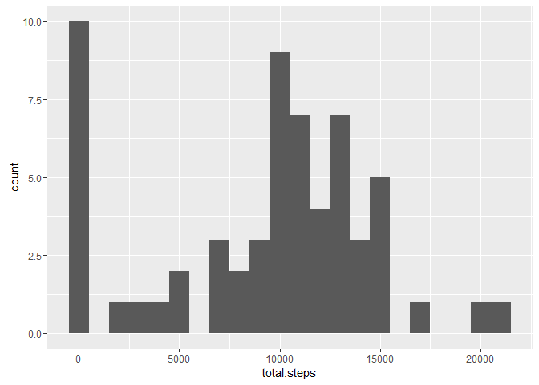

```r
library(ggplot2)
total.steps <- tapply(dataimport$steps, dataimport$date, FUN = sum, na.rm = TRUE)
qplot(total.steps, geom="histogram",binwidth = 1000)
```

```r
mean(total.steps, na.rm = TRUE)
```

```
## [1] 9354.23
```

```r
median(total.steps, na.rm = TRUE)
```

```
## [1] 10395
```

#### 1. Calculate the total number of steps taken per day (ignore the missing values)

```r
require(dplyr)
total_day <- dataimport %>% group_by(date) %>%summarise(total_steps=sum(steps,na.rm=TRUE),na=mean(is.na(steps))) %>% print
```

```
## Source: local data frame [61 x 3]
##
##          date total_steps    na
##        (date)       (int) (dbl)
## 1  2012-10-01           0     1
## 2  2012-10-02         126     0
## 3  2012-10-03       11352     0
## 4  2012-10-04       12116     0
## 5  2012-10-05       13294     0
## 6  2012-10-06       15420     0
## 7  2012-10-07       11015     0
## 8  2012-10-08           0     1
## 9  2012-10-09       12811     0
## 10 2012-10-10        9900     0
## ..        ...         ...   ...
```

Visualise the total number of steps taken per day as a barplot

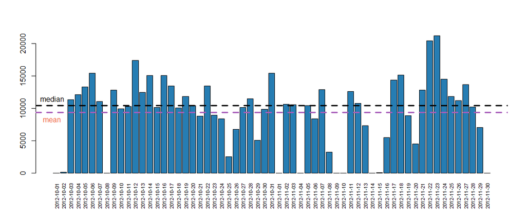

```r
barplot(height = total_day$total_steps,names.arg=total_day$date,cex.names=0.68,las=3,col="#267db3")
abline(h=median(total_day$total_steps), lty=2,lwd=3, col="black")
abline(h=mean(total_day$total_steps), lty=2,lwd=3, col="#a75dba")
text(x = 0,y=median(total_day$total_steps),pos=3,labels = "median")
text(x = 0,y=mean(total_day$total_steps),pos=1,labels = "mean",col="#ed6647")
```

#### 2. Make a histogram of the total number of steps taken each day

Histogram does not contain days where all observations are missing (i.e. there have to be a number of steps for at least one interval for that day, to be included). Otherwise, there would be about ten days with 0 steps.

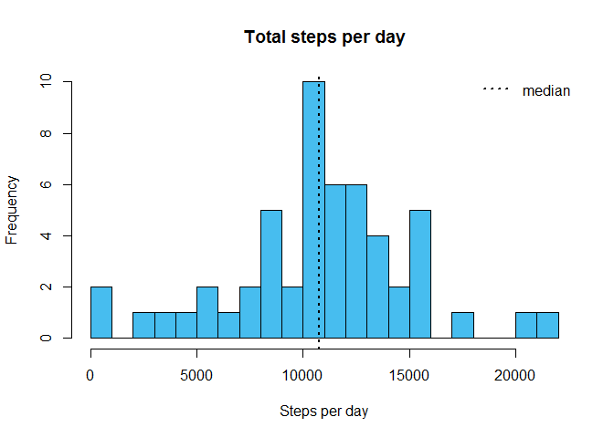

```r
total_day <- filter(total_day, na < 1)
hist(total_day$total_steps,col="#47bdef",breaks=20,main="Total steps per day",xlab="Steps per day")
abline(v=median(total_day$total_steps),lty=3, lwd=2, col="black")
legend(legend="median","topright",lty=3,lwd=2,bty = "n")
```

```r
mean_steps <- mean(total_day$total_steps,na.rm=TRUE)
median_steps <- median(total_day$total_steps,na.rm=TRUE)
```

## What is the average daily activity pattern?

#### 1. Make a time series plot (i.e. type = “l”) of the 5-minute interval (x-axis) and the average number of steps taken, averaged across all days (y-axis)

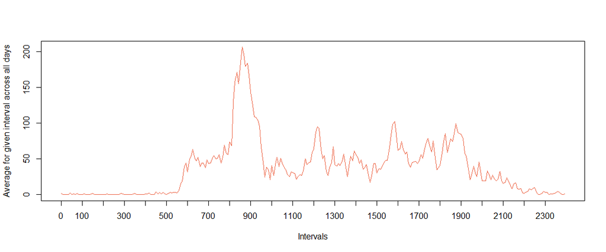

```r
library(dplyr,quietly = TRUE)
daily_patterns <- dataimport %>% group_by(interval) %>% summarise(average=mean(steps,na.rm=TRUE))
plot(x = 1:nrow(daily_patterns),y = daily_patterns$average,type = "l",
     col = "#ed6647", xaxt = "n",xlab="Intervals",
     ylab = "Average for given interval across all days")
axis(1,labels=daily_patterns$interval[seq(1,288,12)],
     at = seq_along(daily_patterns$interval)[seq(1,288,12)])
```

#### 2. Which 5-minute interval, on average across all the days in the dataset, contains the maximum number of steps?

```r
max_numb_steps_interval <- filter(daily_patterns,average==max(average))
```

Interval **“835”** contains on average the maximum number of steps (**206.17 steps**).

## Imputing missing values

#### 1. Calculate and report the total number of missing values in the dataset (i.e. the total number of rows with NAs)

```r
na_number <- sum(is.na(dataimport$steps))
na_number
```

```
## [1] 2304
```

```r
percentage_na <- mean(is.na(dataimport$steps))
percentage_na
```

```
## [1] 0.1311475
```

Total number of missing values in the dataset amounts to **2304** (what is **13.1** % of total observations).

#### 2. Devise a strategy for filling in all of the missing values in the dataset

As the number of missing values in this dataset is fairly large, we cannot be sure if there is no bias introduced by missing values. Therefore we impute missing values based on average number of steps in particular 5-minutes interval.

#### 3. Create a new dataset that is equal to the original dataset but with the missing data filled in.

```r
without_NAs <- numeric(nrow(dataimport))
for (i in 1:nrow(dataimport))
{
        if (is.na(dataimport[i,"steps"])==TRUE)
            {
                    without_NAs[i]<-filter(daily_patterns,interval==dataimport[i,"interval"]) %>% select(average)
            }
        else
            {
                    without_NAs[i]<-dataimport[i,"steps"]
            }

}
dataimport_without_NAs<-mutate(dataimport,steps_no_NAs=without_NAs)
head(dataimport_without_NAs)
```

```
##   steps       date interval steps_no_NAs
## 1    NA 2012-10-01        0     1.716981
## 2    NA 2012-10-01        5    0.3396226
## 3    NA 2012-10-01       10    0.1320755
## 4    NA 2012-10-01       15    0.1509434
## 5    NA 2012-10-01       20    0.0754717
## 6    NA 2012-10-01       25      2.09434
```

Below code is just to verify if process of imputing missing values correctly preserved original values (lines with no NAs)

```r
check <- filter(dataimport_without_NAs,!is.na(steps)) %>% mutate(ok = (steps==steps_no_NAs))
mean(check$ok)
```

```
## [1] 1
```

#### 4. Make a histogram of the total number of steps taken each day and Calculate and report the mean and median total number of steps taken per day

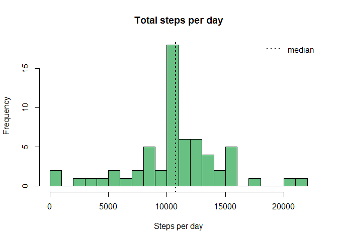

```r
total_day_noNAs <- dataimport_without_NAs %>% mutate(steps_no_NAs=as.numeric(steps_no_NAs)) %>% group_by(date) %>% summarise(total_steps=sum(steps_no_NAs))
hist(total_day_noNAs$total_steps,col="#68c182",breaks=20,main="Total steps per day",xlab="Steps per day")
abline(v=median(total_day$total_steps),lty=3, lwd=2, col="black")
legend(legend="median","topright",lty=3,lwd=2,bty = "n")
```

```r
summary(total_day_noNAs$total_steps)
```

```
##    Min. 1st Qu.  Median    Mean 3rd Qu.    Max.
##      41    9819   10770   10770   12810   21190
```

## Are there differences in activity patterns between weekdays and weekends?

#### 1. Create a new factor variable in the dataset with two levels - “weekday” and “weekend” indicating whether a given date is a weekday or weekend day

```r
library(lubridate)
is_weekday <-function(date){
        if(wday(date)%in%c(1,7)) result<-"weekend"
        else
                result<-"weekday"
        result
}

dataimport_without_NAs <- mutate(dataimport_without_NAs,date=ymd(date)) %>% mutate(day=sapply(date,is_weekday))

table(dataimport_without_NAs$day)
```

```
##
## weekday weekend
##   12960    4608
```

#### 2. Make a panel plot containing a time series plot (i.e. type = “l”) of the 5-minute interval (x-axis) and the average number of steps taken, averaged across all weekday days or weekend days (y-axis)

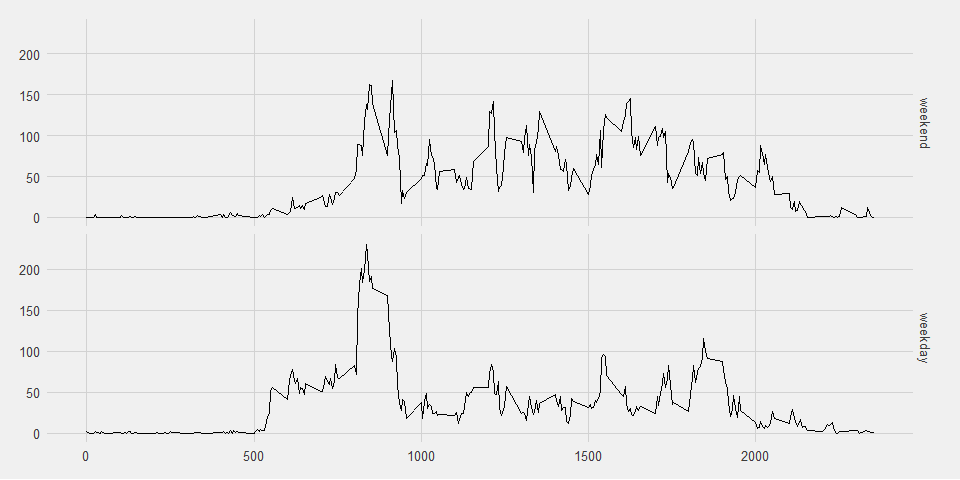

```r
library(ggplot2)
library(ggthemes)
daily_patterns <- dataimport_without_NAs %>% mutate(day=factor(day,levels=c("weekend","weekday")),steps_no_NAs=as.numeric(steps_no_NAs)) %>% group_by(interval,day) %>% summarise(average=mean(steps_no_NAs))
qplot(interval,average,data=daily_patterns,geom="line",facets=day~.) + scale_fill_fivethirtyeight() + theme_fivethirtyeight()
```